```python
import IPython
IPython.display.HTML(\
    '<h1 style="text-align:center">\
        <b>Project nhóm 1</b>\
      </h1>')
```

**Project nhóm 1**

# Danh sách thành viên

[output not shown]

# Phần 1: Giới thiệu

Tên đề tài: **Xây dựng mô hình dự đoán để dự đoán sự trì hoãn của các chuyến bay**

## **1.1. Giới thiệu đề tài:**

- Sự trì hoãn của chuyến bay có thể gây ra nhiều rắc rối cho các hãng hàng không, hành khách và các bên khai thác sân bay. Các hãng hàng không có thể phải chịu thêm chi phí cho nhân viên, nhiên liệu và cơ sở hạ tầng. Hành khách có thể bị gián đoạn kế hoạch đi lại và phải chịu những bất tiện khác. Các bên khai thác sân bay có thể phải đối mặt với việc tắc nghẽn, ùn ứ hàng hoá và giảm hiệu quả hoạt động. Đi kèm với đó, sự gia tăng của lượng khách du lịch trong nước và ngoài nước và sự phức tạp của hoạt động hàng không đã khiến cho tầm quan trọng của việc dự đoán sự trì hoãn của các chuyến bay ngày càng được chú ý.
- Việc giải quyết bài toán dự đoán sự trì hoãn của chuyến bay sẽ giúp các hãng hàng không, hành khách và các nhà khai thác sân bay giảm thiểu những tác động tiêu cực của sự trì hoãn, cụ thể như:
1. Các hãng hàng không có thể sử dụng mô hình dự đoán để xác định các chuyến bay có nguy cơ bị trì hoãn cao. Điều này sẽ giúp các hãng hàng không có kế hoạch dự phòng để giảm thiểu thiệt hại do sự trì hoãn gây ra. Ví dụ, các hãng hàng không có thể điều động thêm nhân viên, nhiên liệu hoặc máy bay để giải quyết các chuyến bay bị trì hoãn.
2. Hành khách có thể sử dụng mô hình dự đoán để biết trước khả năng chuyến bay của họ bị trì hoãn. Điều này sẽ giúp hành khách chủ động sắp xếp lịch trình của mình để tránh những bất tiện do sự trì hoãn gây ra. Ví dụ, hành khách có thể đặt phòng khách sạn hoặc vé tàu hỏa dự phòng để phòng trường hợp chuyến bay của họ bị trì hoãn.
3. Các bên khai thác sân bay có thể sử dụng mô hình dự đoán để xác định các thời điểm và địa điểm có nguy cơ xảy ra sự trì hoãn cao. Điều này sẽ giúp họ có kế hoạch điều phối và quản lý các chuyến bay để giảm thiểu tắc nghẽn và cải thiện hiệu quả hoạt động.
- Từ đó, mục tiêu của dự án là thực hiện phân tích dữ liệu lịch sử chuyến bay để thu được những hiểu biết có giá trị và xây dựng mô hình dự đoán để dự đoán liệu chuyến bay sẽ bị trì hoãn hay không khi được cung cấp một bộ đặc điểm chuyến bay.

**Các câu hỏi cần được giải đáp:**

1. Dự đoán chuyến bay nào sẽ bị hoãn hoặc bị huỷ
2. Dự đoán thời gian hoãn của chuyến bay
3. So sánh sự trì hoãn của các hãng hàng không
4. Xác định sân bay nào bị chậm trễ nhất?
5. Xác định những tuyến đường nào thường bị chậm trễ nhất?
6. Xác định thời gian chậm trễ tại sân bay tại điểm khởi hành mỗi tháng
7. Xác định thời gian trì hoãn tại sân bay tại điểm khởi hành mỗi ngày/giờ
8. Kết luận nguyên nhân chính dẫn đến sự chậm trễ chuyến bay là gì?

## **1.2. Giới thiệu tổng quan Dataset**

### 1.2.1. Nguồn dữ liệu sử dụng

- Mô hình sử dụng tập dữ liệu **Flight Status Prediction** từ trang kaggle.com
- Người đăng tập dữ liệu: Rob Mulla
- Đường dẫn tập dữ liệu: https://www.kaggle.com/datasets/robikscube/flight-delay-dataset-20182022

### 1.2.2. Giới thiệu nơi cấp dữ liệu

- Kaggle là một trang web cộng đồng trực tuyến dành cho các nhà khoa học dữ liệu và các nhà phát triển. Trang web này cung cấp một kho dữ liệu và mô hình khổng lồ, cũng như các cuộc thi và cộng đồng để người dùng có thể chia sẻ và học hỏi lẫn nhau.
- Kaggle có một kho dữ liệu khổng lồ, bao gồm dữ liệu từ nhiều lĩnh vực khác nhau, chẳng hạn như khoa học, kỹ thuật, kinh doanh và tài chính. Dữ liệu trên Kaggle có thể được sử dụng miễn phí cho mục đích học tập và nghiên cứu.
- Kaggle cũng có một kho mô hình khổng lồ, bao gồm các mô hình học máy đã được đào tạo trên các tập dữ liệu khác nhau. Mô hình trên Kaggle có thể được sử dụng để giải quyết các vấn đề thực tế.
- Kaggle có một cộng đồng lớn và tích cực của các nhà khoa học dữ liệu và các nhà phát triển. Cộng đồng này cung cấp một nơi để người dùng có thể chia sẻ ý tưởng, học hỏi lẫn nhau và tìm kiếm sự trợ giúp.

# Phần 2: Chuẩn bị

## 2.1: Nhập thư viện

```python
# Thư viện spark
#Thư viện toán học, dataframe, biểu đồ
import pandas as pd
import numpy as np
import seaborn as sns
import matplotlib.pyplot as plt
from pyspark.ml import Pipeline

#Thư viện Pyspark
from pyspark.sql import SparkSession
from pyspark import SparkConf
from pyspark.context import SparkContext
from pyspark.ml.feature import OneHotEncoder, StringIndexer, VectorAssembler
from pyspark.ml.feature import StandardScaler, Imputer
from pyspark.sql import functions as f
from pyspark.sql.window import Window
from pyspark.sql import SQLContext
from pyspark.sql.functions import mean, stddev, col
from pyspark.sql.types import StructType, StructField, StringType, DoubleType, IntegerType, NullType
from pyspark.sql.functions import to_timestamp
from pyspark.sql import functions

#Thư viện machine learning
import pyspark.ml as ml
from pyspark.ml.feature import StringIndexer
from pyspark.ml.classification import DecisionTreeClassifier,RandomForestClassifier,GBTClassifier,LogisticRegression,NaiveBayes
from pyspark.mllib.linalg.distributed import RowMatrix
from pyspark.ml.tuning import ParamGridBuilder
from pyspark.ml.tuning import CrossValidator
from pyspark.ml.tuning import TrainValidationSplit
from pyspark.ml import PipelineModel
from pyspark.mllib.linalg import Vectors
from pyspark.ml.feature import PCA
from pyspark.ml.evaluation import MulticlassClassificationEvaluator
```

```python
spark = SparkSession\
        .builder\
        .config("spark.driver.memory", "15g")\
        .appName("Predicting Flight Delay").getOrCreate()
```

## 2.2: Kiểm tra phiên bản của Spark

```python
spark
```

**SparkSession - in-memory**

**SparkContext**

[Spark UI](http://192.168.221.1:4040)

**Version**

`v3.5.0`

**Master**

`local[*]`

**AppName**

`Predicting Flight Delay`

## 2.3: Tạo spark context:

```python
# sc = SparkContext.getOrCreate()
sqlContext = SQLContext(spark)
```

## 2.4: Đọc tập dữ liệu

```python
df = sqlContext.read.format(
    "csv").option("header", "true").load("../data/Combined_Flights_2018.csv",
    inferSchema=True)
```

# Phần 3: Chi tiết tập dữ liệu

Kích thước của tập dữ liệu:

```python
print("\t Dữ liệu có kích thước là: " + str(df.count())+"x"+str(len(df.columns)))
```

```
	 Dữ liệu có kích thước là: 5689512x61
```

10 dòng đầu tiên của tập dữ liệu:

```python
df.show(10,0)
```

```
+----------+-----------------+------+----+---------+--------+----------+-------+---------------+--------+-------+---------------+-------+--------------+-----------------+--------+----+-------+-----+----------+---------+-------------------------+---------------------------------------+---------------…
|FlightDate|Airline          |Origin|Dest|Cancelled|Diverted|CRSDepTime|DepTime|DepDelayMinutes|DepDelay|ArrTime|ArrDelayMinutes|AirTime|CRSElapsedTime|ActualElapsedTime|Distance|Year|Quarter|Month|DayofMonth|DayOfWeek|Marketing_Airline_Network|Operated_or_Branded_Code_Share_Partners|DOT_ID_Marketin…
+----------+-----------------+------+----+---------+--------+----------+-------+---------------+--------+-------+---------------+-------+--------------+-----------------+--------+----+-------+-----+----------+---------+-------------------------+---------------------------------------+---------------…
|2018-01-23|Endeavor Air Inc.|ABY   |ATL |false    |false   |1202      |1157.0 |0.0            |-5.0    |1256.0 |0.0            |38.0   |62.0          |59.0             |145.0   |2018|1      |1    |23        |2        |DL                       |DL_CODESHARE                           |19790          …
|2018-01-24|Endeavor Air Inc.|ABY   |ATL |false    |false   |1202      |1157.0 |0.0            |-5.0    |1258.0 |0.0            |36.0   |62.0          |61.0             |145.0   |2018|1      |1    |24        |3        |DL                       |DL_CODESHARE                           |19790          …
|2018-01-25|Endeavor Air Inc.|ABY   |ATL |false    |false   |1202      |1153.0 |0.0            |-9.0    |1302.0 |0.0            |40.0   |62.0          |69.0             |145.0   |2018|1      |1    |25        |4        |DL                       |DL_CODESHARE                           |19790          …
|2018-01-26|Endeavor Air Inc.|ABY   |ATL |false    |false   |1202      |1150.0 |0.0            |-12.0   |1253.0 |0.0            |35.0   |62.0          |63.0             |145.0   |2018|1      |1    |26        |5        |DL                       |DL_CODESHARE                           |19790          …
|2018-01-27|Endeavor Air Inc.|ABY   |ATL |false    |false   |1400      |1355.0 |0.0            |-5.0    |1459.0 |0.0            |36.0   |60.0          |64.0             |145.0   |2018|1      |1    |27        |6        |DL                       |DL_CODESHARE                           |19790          …
|2018-01-28|Endeavor Air Inc.|ABY   |ATL |false    |false   |1202      |1202.0 |NULL           |NULL    |1326.0 |22.0           |37.0   |62.0          |84.0             |145.0   |2018|1      |1    |28        |7        |DL                       |DL_CODESHARE                           |19790          …
|2018-01-29|Endeavor Air Inc.|ABY   |ATL |false    |false   |1202      |1204.0 |2.0            |2.0     |1303.0 |0.0            |34.0   |62.0          |59.0             |145.0   |2018|1      |1    |29        |1        |DL                       |DL_CODESHARE                           |19790          …
|2018-01-30|Endeavor Air Inc.|ABY   |ATL |false    |false   |1202      |1153.0 |0.0            |-9.0    |1255.0 |0.0            |44.0   |62.0          |62.0             |145.0   |2018|1      |1    |30        |2        |DL                       |DL_CODESHARE                           |19790          …
|2018-01-31|Endeavor Air Inc.|ABY   |ATL |false    |false   |1202      |1153.0 |0.0            |-9.0    |1304.0 |NULL           |37.0   |62.0          |71.0             |145.0   |2018|1      |1    |31        |3        |DL                       |DL_CODESHARE                           |19790          …
|2018-01-03|Endeavor Air Inc.|ATL   |ABY |false    |false   |1037      |1101.0 |24.0           |24.0    |1159.0 |22.0           |32.0   |60.0          |58.0             |145.0   |2018|1      |1    |3         |3        |DL                       |DL_CODESHARE                           |19790          …
+----------+-----------------+------+----+---------+--------+----------+-------+---------------+--------+-------+---------------+-------+--------------+-----------------+--------+----+-------+-----+----------+---------+-------------------------+---------------------------------------+---------------…
only showing top 10 rows
```

Schema của tập dữ liệu:

```python
df.printSchema()
```

```
root
 |-- FlightDate: date (nullable = true)
 |-- Airline: string (nullable = true)
 |-- Origin: string (nullable = true)
 |-- Dest: string (nullable = true)
 |-- Cancelled: boolean (nullable = true)
 |-- Diverted: boolean (nullable = true)
 |-- CRSDepTime: integer (nullable = true)
 |-- DepTime: double (nullable = true)
 |-- DepDelayMinutes: double (nullable = true)
 |-- DepDelay: double (nullable = true)
 |-- ArrTime: double (nullable = true)
 |-- ArrDelayMinutes: double (nullable = true)
 |-- AirTime: double (nullable = true)
 |-- CRSElapsedTime: double (nullable = true)
 |-- ActualElapsedTime: double (nullable = true)
 |-- Distance: double (nullable = true)
 |-- Year: integer (nullable = true)
 |-- Quarter: integer (nullable = true)
 |-- Month: integer (nullable = true)
 |-- DayofMonth: integer (nullable = true)
 |-- DayOfWeek: integer (nullable = true)
 |-- Marketing_Airline_Network: string (nullable = true)
 |-- Operated_or_Branded_Code_Share_Partners: string (nullable = true)
 |-- DOT_ID_Marketing_Airline: integer (nullable = true)
 |-- IATA_Code_Marketing_Airline: string (nullable = true)
 |-- Flight_Number_Marketing_Airline: integer (nullable = true)
 |-- Operating_Airline: string (nullable = true)
 |-- DOT_ID_Operating_Airline: integer (nullable = true)
 |-- IATA_Code_Operating_Airline: string (nullable = true)
 |-- Tail_Number: string (nullable = true)
 |-- Flight_Number_Operating_Airline: integer (nullable = true)
 |-- OriginAirportID: integer (nullable = true)
 |-- OriginAirportSeqID: integer (nullable = true)
 |-- OriginCityMarketID: integer (nullable = true)
 |-- OriginCityName: string (nullable = true)
 |-- OriginState: string (nullable = true)
 |-- OriginStateFips: integer (nullable = true)
 |-- OriginStateName: string (nullable = true)
 |-- OriginWac: integer (nullable = true)
 |-- DestAirportID: integer (nullable = true)
 |-- DestAirportSeqID: integer (nullable = true)
 |-- DestCityMarketID: integer (nullable = true)
 |-- DestCityName: string (nullable = true)
 |-- DestState: string (nullable = true)
 |-- DestStateFips: integer (nullable = true)
 |-- DestStateName: string (nullable = true)
 |-- DestWac: integer (nullable = true)
 |-- DepDel15: double (nullable = true)
 |-- DepartureDelayGroups: double (nullable = true)
 |-- DepTimeBlk: string (nullable = true)
 |-- TaxiOut: double (nullable = true)
 |-- WheelsOff: double (nullable = true)
 |-- WheelsOn: double (nullable = true)
 |-- TaxiIn: double (nullable = true)
 |-- CRSArrTime: integer (nullable = true)
 |-- ArrDelay: double (nullable = true)
 |-- ArrDel15: double (nullable = true)
 |-- ArrivalDelayGroups: double (nullable = true)
 |-- ArrTimeBlk: string (nullable = true)
 |-- DistanceGroup: integer (nullable = true)
 |-- DivAirportLandings: double (nullable = true)
```

Miêu tả các biến của tập dữ liệu:

| Column | Description |
| --- | --- |
| FlightDate | Thời điểm chuyến bay (yyyymmdd) |
| Airline | Hãng hàng không |
| Origin | Mã sân bay khởi hành |
| Dest | Mã sân bay đích |
| Cancelled | Chuyến bay có bị huỷ hay không (1=Có) |
| Diverted | Chuyến bay có chuyển hướng hay không(1=Có) |
| CRSDepTime | Giờ khởi hành dự kiến (local time: hhmm) |
| DepTime | Giờ khởi hành thực tế (local time: hhmm) |
| DepDelayMinutes | Khoảng cách theo phút giữa giờ khởi hành dự kiến và thực tế. Nếu khởi hành sớm hơn dự kiến thì đặt là 0. |
| DepDelay | Khoảng cách theo phút giữa giờ khởi hành dự kiến và thực tế. |
| ArrTime | Giờ đến thực tế (local time: hhmm) |
| ArrDelayMinutes | Khoảng cách theo phút giữa giờ đến dự kiến và thực tế. Nếu đến sớm hơn dự kiến thì đặt là 0. |
| ArrDelay | Khoảng cách theo phút giữa giờ đến dự kiến và thực tế. |
| AirTime | Thời gian trên không, theo phút |
| CRSElapsedTime | Tổng thời gian bay dự kiến theo phút |
| ActualElapsedTime | Tổng thời gian bay thực tế theo phút |
| Distance | Khoảng cách giữa các sân bay (miles) |
| Year | Năm |
| Quarter | Quý (1-4) |
| Month | Tháng |
| DayofMonth | Ngày trong tháng |
| DayOfWeek | Ngày trong tuần |
| Marketing_Airline_Network | Mã đặc trưng của Marketing Carrier. Trong trường hợp cùng một mã được sử dụng bởi nhiều nhà cung cấp, một hậu tố số sẽ được thêm vào cho những nhà cung cấp trước đó, ví dụ: PA, PA(1), PA(2). |
| Operated_or_Branded_Code_Share_Partners | Đối tác chia sẻ mã hoạt động hoặc mang thương hiệu của nhà cung cấp báo cáo |
| DOT_ID_Marketing_Airline | Một mã số nhận dạng do Bộ Giao thông vận tải Hoa Kỳ (US DOT) cấp để xác định duy nhất một hãng hàng không (carrier). Một hãng hàng không (carrier) duy nhất được định nghĩa là hãng nắm giữ và báo cáo t… |
| IATA_Code_Marketing_Airline | Mã IATA: Mã này do Hiệp hội Vận tải Hàng không Quốc tế (IATA) cấp và thường được sử dụng để nhận dạng nhà vận chuyển. Tuy nhiên, mã IATA không phải lúc nào cũng duy nhất vì cùng một mã có thể được cấp… |
| Flight_Number_Marketing_Airline | Mã số chuyến bay |
| Operating_Airline | Mã đặc trưng của Airline Carrier. Trong trường hợp cùng một mã được sử dụng bởi nhiều nhà cung cấp, một hậu tố số sẽ được thêm vào cho những nhà cung cấp trước đó, ví dụ: PA, PA(1), PA(2). |
| DOT_ID_Operating_Airline | Một mã số nhận dạng do Bộ Giao thông vận tải Hoa Kỳ (US DOT) cấp để xác định duy nhất một hãng hàng không (carrier). Một hãng hàng không (carrier) duy nhất được định nghĩa là hãng nắm giữ và báo cáo t… |
| IATA_Code_Operating_Airline | Mã IATA: Mã này do Hiệp hội Vận tải Hàng không Quốc tế (IATA) cấp và thường được sử dụng để nhận dạng nhà vận chuyển. Tuy nhiên, mã IATA không phải lúc nào cũng duy nhất vì cùng một mã có thể được cấp… |
| Tail_Number | Mã định danh trên đuôi máy bay |
| Flight_Number_Operating_Airline | Mã số chuyến bay |
| OriginAirportID | Mã định danh sân bay khởi hành là một mã nhận dạng duy nhất được Cục Giao thông vận tải Hoa Kỳ (US DOT) cấp cho từng sân bay |
| OriginAirportSeqID | Mã định danh Sequence sân bay là một mã nhận dạng duy nhất được Cục Giao thông vận tải Hoa Kỳ (US DOT) cấp cho từng sân bay |
| OriginCityMarketID | Mã City Market sân bay là một mã nhận dạng duy nhất được Cục Giao thông vận tải Hoa Kỳ (US DOT) cấp cho từng sân bay |
| OriginCityName | Tên thành phố chứa sân bay khởi hành |
| OriginState | Mã bang của sân bay khởi hành |
| OriginStateFips | Mã Fips của bang có sân bay khởi hành |
| OriginStateName | Tên bang, sân bay khởi hành |
| OriginWac | Mã số điện thoại quốc tế của sân bay khởi hành |
| DestAirportID | Mã định danh sân bay đích đến là một mã nhận dạng duy nhất được Cục Giao thông vận tải Hoa Kỳ (US DOT) cấp cho từng sân bay. |
| DestAirportSeqID | Mã định danh Sequence sân bay đích đến là một mã nhận dạng duy nhất được Cục Giao thông vận tải Hoa Kỳ (US DOT) cấp cho từng sân bay. |
| DestCityMarketID | Mã định danh City Market sân bay đích đến là một mã nhận dạng duy nhất được Cục Giao thông vận tải Hoa Kỳ (US DOT) cấp cho từng sân bay. |
| DestCityName | Tên thành phố, sân bay đích đến |
| DestState | Mã bang, sân bay đích đến |
| DestStateFips | Mã Fips của bang, sân bay đích đến |
| DestStateName | Tên bang, sân bay đích đến |
| DestWac | Mã số điện thoại quốc tế của sân bay đích đến |
| DepDel15 | Dấu hiệu máy bay cất cánh trễ, 15 phút thì tính (1=Yes) |
| DepartureDelayGroups | Khoảng thời gian hoãn khi đến, (tính theo mỗi 15 phút) |
| DepTimeBlk | Khối thời gian đến dự kiến, Khoảng thời gian tính theo giờ |
| TaxiOut | Thời gian máy bay chạy trên đường băng đến khi cất cánh , tính theo phút |
| WheelsOff | Thời điểm càng hạ cánh máy bay thu vào khi cất cánh (local time: hhmm) |
| WheelsOn | Thời điểm càng hạ cánh mở ra khi hạ cánh (local time: hhmm) |
| TaxiIn | Thời gian máy bay chạy trên đường băng đến khi hạ cánh, tính theo phút |
| CRSArrTime | Thời gian đến dự kiến (local time: hhmm) |
| ArrDelay | Khoảng cách thời gian theo phút giữa thời gian đến dự kiến và thực tế. Nếu đến sớm hơn thì số âm. |
| ArrDel15 | Dấu hiệu máy bay đến trễ(1=Yes) |
| ArrivalDelayGroups | Khoảng thời gian trễ khi máy bay đến (15-minutes from 180) |
| ArrTimeBlk | Khối thời gian đến dự tính, Khoảng thời gian tính theo giờ |
| DistanceGroup | Các khoảng cách theo mỗi 250 dặm, cho từng chặng bay |
| DivAirportLandings | Số lần máy bay hạ cánh đến sân bay ngoài dự kiến |

# Phần 4: Tiền xử lí dữ liệu

Bước 1: Xử lí dữ liệu bị null và thay thế giá trị bị null bằng giá trị 0

```python
print("Số dòng có giá trị null: ",df.na.drop().count())
df = df.fillna(0)
```

```
Số dòng có giá trị null:  5578618
```

Bước 2: Chỉ sử dụng những chuyến bay không bị huỷ - Cancelled - hoặc không bị chuyển hướng - Diverted:

```python
df = df.filter((df.Cancelled == 0)&(df.Diverted == 0))
df.filter((df.Cancelled != 0)|(df.Diverted != 0)).toPandas().to_csv('../data/Cancelled_Or_Diverted_Flights.csv')
df = df.withColumn('Delayed', (df.ArrDelay >=15).cast('int'))
```

Bước 3: Khai báo dataframe thành table trong SQLContext:

```python
sqlContext.registerDataFrameAsTable(df, "df")
```

Bước 4: Tạo thêm cột TimeSlot dựa trên CRSDepTime:

- CRSDepTime <= 800 thì TimeSlot = 1
- 800 < CRSDepTime <= 1200 thì TimeSlot = 2
- 1200 < CRSDepTime <= 1600 thì TimeSlot = 3
- 1600 < CRSDepTime <= 2100 thì TimeSlot = 4

```python
df = sqlContext.sql("select *, case \
               when CRSDepTime <= 800 then 1 \
               when 800 < CRSDepTime and CRSDepTime <= 1200 then 2 \
               when 1200 < CRSDepTime and CRSDepTime <= 1600 then 3 \
               when 1600 < CRSDepTime and CRSDepTime <= 2100 then 4 \
               else 1 end as TimeSlot \
               from df")
```

Ép kiểu dữ liệu:

```python
df = df.withColumn("FlightDate", to_timestamp(df["FlightDate"], "MM/dd/yyyy"))
```

```python
df.limit(10).show()
```

```
+-------------------+-----------------+------+----+---------+--------+----------+-------+---------------+--------+-------+---------------+-------+--------------+-----------------+--------+----+-------+-----+----------+---------+-------------------------+---------------------------------------+------…
|         FlightDate|          Airline|Origin|Dest|Cancelled|Diverted|CRSDepTime|DepTime|DepDelayMinutes|DepDelay|ArrTime|ArrDelayMinutes|AirTime|CRSElapsedTime|ActualElapsedTime|Distance|Year|Quarter|Month|DayofMonth|DayOfWeek|Marketing_Airline_Network|Operated_or_Branded_Code_Share_Partners|DOT_ID…
+-------------------+-----------------+------+----+---------+--------+----------+-------+---------------+--------+-------+---------------+-------+--------------+-----------------+--------+----+-------+-----+----------+---------+-------------------------+---------------------------------------+------…
|2018-01-23 00:00:00|Endeavor Air Inc.|   ABY| ATL|    false|   false|      1202| 1157.0|            0.0|    -5.0| 1256.0|            0.0|   38.0|          62.0|             59.0|   145.0|2018|      1|    1|        23|        2|                       DL|                           DL_CODESHARE|      …
|2018-01-24 00:00:00|Endeavor Air Inc.|   ABY| ATL|    false|   false|      1202| 1157.0|            0.0|    -5.0| 1258.0|            0.0|   36.0|          62.0|             61.0|   145.0|2018|      1|    1|        24|        3|                       DL|                           DL_CODESHARE|      …
|2018-01-25 00:00:00|Endeavor Air Inc.|   ABY| ATL|    false|   false|      1202| 1153.0|            0.0|    -9.0| 1302.0|            0.0|   40.0|          62.0|             69.0|   145.0|2018|      1|    1|        25|        4|                       DL|                           DL_CODESHARE|      …
|2018-01-26 00:00:00|Endeavor Air Inc.|   ABY| ATL|    false|   false|      1202| 1150.0|            0.0|   -12.0| 1253.0|            0.0|   35.0|          62.0|             63.0|   145.0|2018|      1|    1|        26|        5|                       DL|                           DL_CODESHARE|      …
|2018-01-27 00:00:00|Endeavor Air Inc.|   ABY| ATL|    false|   false|      1400| 1355.0|            0.0|    -5.0| 1459.0|            0.0|   36.0|          60.0|             64.0|   145.0|2018|      1|    1|        27|        6|                       DL|                           DL_CODESHARE|      …
|2018-01-28 00:00:00|Endeavor Air Inc.|   ABY| ATL|    false|   false|      1202| 1202.0|            0.0|     0.0| 1326.0|           22.0|   37.0|          62.0|             84.0|   145.0|2018|      1|    1|        28|        7|                       DL|                           DL_CODESHARE|      …
|2018-01-29 00:00:00|Endeavor Air Inc.|   ABY| ATL|    false|   false|      1202| 1204.0|            2.0|     2.0| 1303.0|            0.0|   34.0|          62.0|             59.0|   145.0|2018|      1|    1|        29|        1|                       DL|                           DL_CODESHARE|      …
|2018-01-30 00:00:00|Endeavor Air Inc.|   ABY| ATL|    false|   false|      1202| 1153.0|            0.0|    -9.0| 1255.0|            0.0|   44.0|          62.0|             62.0|   145.0|2018|      1|    1|        30|        2|                       DL|                           DL_CODESHARE|      …
|2018-01-31 00:00:00|Endeavor Air Inc.|   ABY| ATL|    false|   false|      1202| 1153.0|            0.0|    -9.0| 1304.0|            0.0|   37.0|          62.0|             71.0|   145.0|2018|      1|    1|        31|        3|                       DL|                           DL_CODESHARE|      …
|2018-01-03 00:00:00|Endeavor Air Inc.|   ATL| ABY|    false|   false|      1037| 1101.0|           24.0|    24.0| 1159.0|           22.0|   32.0|          60.0|             58.0|   145.0|2018|      1|    1|         3|        3|                       DL|                           DL_CODESHARE|      …
+-------------------+-----------------+------+----+---------+--------+----------+-------+---------------+--------+-------+---------------+-------+--------------+-----------------+--------+----+-------+-----+----------+---------+-------------------------+---------------------------------------+------…
```

# Phần 5: Trực quan hoá dữ liệu:

## 5.1. Top 10 hãng hàng không khai thác nhiều chuyến bay nhất trên thế giới:

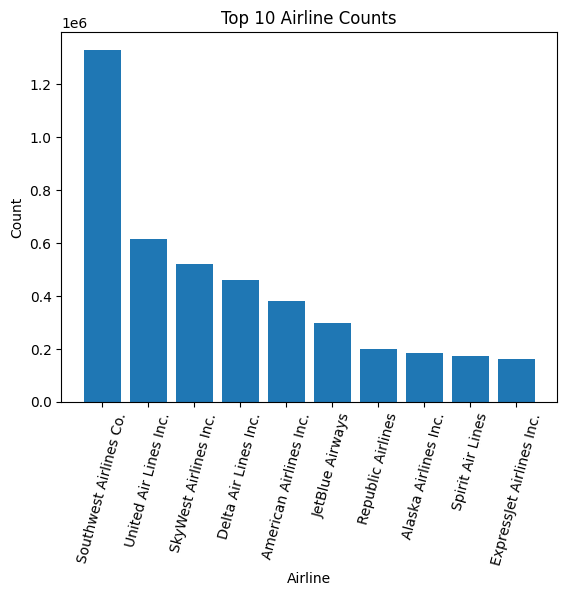

```python
df_temp = df.groupBy("Airline").count().orderBy("count", ascending=False)
df_temp = df_temp.limit(10).select('*').toPandas()
# Plot the column chart
plt.bar(df_temp["Airline"], df_temp["count"])
plt.xlabel("Airline")
plt.ylabel("Count")
plt.title("Top 10 Airline Counts")
plt.xticks(rotation=75)
plt.show()
```

### Nhận xét:

- Sau khi phân tích ra top 10 hãng hàng không khai thác nhiều chuyến bay nhất trên thế giới biểu đồ cột cho thấy số lượng chuyến bay của hãng hàng không Southwest Airlines Co. có số lần bay nhiều nhất giữa các hãng hàng không khác cho thấy hãng hàng không này được khách hàng lựa chọn và ưu thích nhất ở mặt bằng trung.

## 5.2. Hãng hàng không càng lớn thì tỉ lệ delay sẽ thế nào:

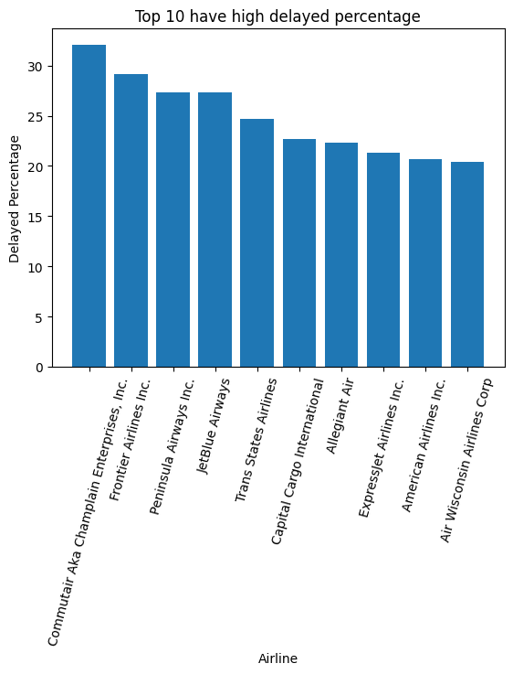

```python
df_temp = df.groupBy("Airline")\
    .agg(
        f.count("Airline").alias("count"),
        f.count(f.when(df["Delayed"] == 1, 1)).alias('count_delayed')
        )\
    .withColumn("delayed_percent", f.col("count_delayed") / f.col("count") * 100)\
    .orderBy("count", ascending=False).orderBy("delayed_percent",ascending = False).limit(10).toPandas()

plt.bar(df_temp["Airline"], df_temp["delayed_percent"])
plt.xlabel("Airline")
plt.ylabel("Delayed Percentage")
plt.title("Top 10 have high delayed percentage")
plt.xticks(rotation=75)
plt.show()
```

## 5.3. Sử dụng Heat Map để thể hiện độ tương quan của các biến với nhau:

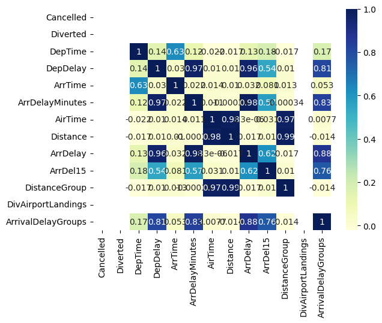

```python
# Select the relevant columns for correlation analysis
cols = ["Cancelled", "Diverted","DepTime", "DepDelay", "ArrTime",
        "ArrDelayMinutes", "AirTime","Distance","ArrDelay", "ArrDel15", "DistanceGroup", "DivAirportLandings","ArrivalDelayGroups"]

# Compute the correlation matrix for the selected columns
corr_matrix = df.select(cols).toPandas().corr()

# Plot the heatmap
sns.heatmap(corr_matrix, annot=True, cmap="YlGnBu")

# Show the plot
plt.show()
```

### Nhận xét:

Độ tương quan cao: Airtime và Distance, ArrDelay và DepDelay

## 5.4. Kiểm tra độ tương quan của 2 biến ArrDelay và DepDelay

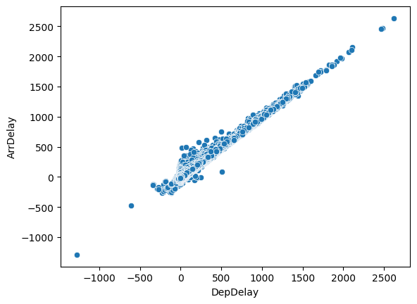

```python
df_temp = df.select("DepDelay", "ArrDelay").toPandas()
sns.scatterplot(x="DepDelay", y="ArrDelay", data=df_temp)

plt.show()
```

### Nhận xét:

- Ta thấy mật độ 2 biến ArrDelay và DepDelay về phần lớn trung bình phân bổ đồng đều với nhau, phần còn lại các điểm dữ liệu ArrDelay sẽ có một số nhiều hơn điểm dữ liệu DepDelay

## 5.5. Độ tương quan giữa thời gian bay và khoảng cách bay

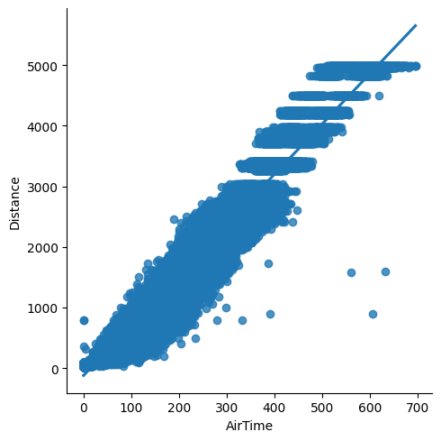

```python
# Convert PySpark DataFrame to Pandas DataFrame
df_temp = df.select(["AirTime", "Distance"]).filter((df.AirTime >=0 ) & (df.Distance >=0)).toPandas()

# Create scatterplot with linear regression line
sns.lmplot(x="AirTime", y="Distance", data=df_temp)

# Show the plot
plt.show()
```

### Nhận xét:

- Ta thấy khi mật độ điểm càng lên cao thì càng đẩy về phía bên trái nhiều hơn bên phải tức là khoảng cách bay đang là mục tiêu đánh giá vì sao trễ chuyến hơn là thời gian bay

## 5.6. Độ tương quan giữa thời gian trễ hạ cánh và thời gian trễ cất cánh

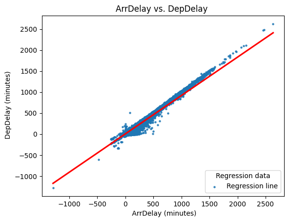

```python
sns.regplot(x=df.select("ArrDelay").toPandas(), y=df.select("DepDelay").toPandas(), scatter_kws={"s": 5}, line_kws={"color": "red"}, label="Regression line")


# Set plot title and axis labels
plt.title("ArrDelay vs. DepDelay ")
plt.xlabel(" ArrDelay (minutes)")
plt.ylabel(" DepDelay (minutes)")

# Show the legend with the regression data
plt.legend(title="Regression data", loc="lower right")

# Show the plot
plt.show()
```

### Nhận xét:

- Ta thấy độ trễ khi khởi hành so với độ trễ khi đến là khá cao cho thấy độ trễ chuyến bay hầu như đều do độ trễ khi chuyến bay đó bắt đầu khởi hành

## 5.7. Thời gian khởi hành trễ trung bình của các hãng hàng không

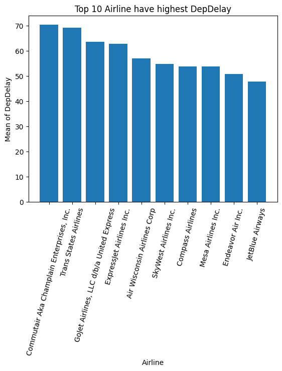

```python
df_temp = df.filter(df.DepDelay > 0).groupBy("Airline").agg(mean("DepDelay").alias("mean_DepDelay")).orderBy("mean_DepDelay",ascending= False).limit(10).toPandas()
plt.bar(df_temp["Airline"], df_temp["mean_DepDelay"])
plt.xlabel("Airline")
plt.ylabel("Mean of DepDelay")
plt.title("Top 10 Airline have highest DepDelay")
plt.xticks(rotation=75)
plt.show()
```

## 5.8. Sự phân bố của lượng thời gian cất cánh trễ và thời gian hạ cánh trễ

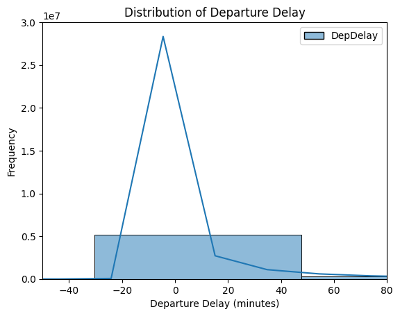

```python
df_temp = df.select("DepDelay").toPandas()
sns.histplot(df_temp, bins=50, kde=True)

# Set plot title and axis labels
plt.title("Distribution of Departure Delay")
plt.xlabel("Departure Delay (minutes)")
plt.ylabel("Frequency")
plt.axis([-50, 80, 0, 30000000])
# Show the plot
plt.show()
```

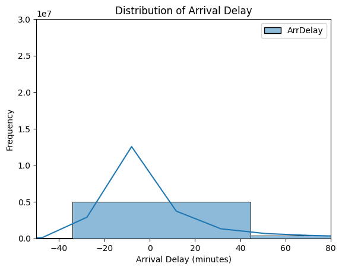

```python
df_temp = df.select("ArrDelay").toPandas()
sns.histplot(df_temp, bins=50, kde=True)

# Set plot title and axis labels
plt.title("Distribution of Arrival Delay")
plt.xlabel("Arrival Delay (minutes)")
plt.ylabel("Frequency")
plt.axis([-50, 80, 0, 30000000])
# Show the plot
plt.show()
```

# Phần 6: Phương pháp

## 6.1. Các thuật toán phân loại – Classification:

### 6.1.1. Hồi quy logistic

Hồi quy logistic là một kỹ thuật phân tích dữ liệu sử dụng toán học để tìm ra mối quan hệ giữa hai yếu tố dữ liệu. Mô hình hồi quy logistic được ứng dụng trong dự đoán đối tượng thuộc vào một trong hai nhóm. Hồi quy logistic sử dụng nguyên lí của hàm sigmoid. [2]

Hàm sigmoid là một hàm phi tuyến biến đổi đầu vào thành xác suất tương ứng với một trong hai lớp nhị phân. Hàm sigmoid được diễn giải sau đây:

$$ S(z)= \frac {1}{1+e^{-z}} $$

Với z bất kì, hàm sigmoid trả về đầu ra là một giá trị xác suất nằm trong khoảng [0;1]. Tương tự, ta có z=Xω nếu đầu vào là một ma trận dữ liệu X và trọng số ω. [2]

Hàm mất mát của bài toán hồi quy logistic là hàm mất mát Cross-Entropy. Hàm mất mát này được định nghĩa như sau: [2]

$$ L(ω)= -1/n ∑_(i=1)^ny_i log p_i+(1-y_i ) log(1-p_i ) $$

Với:

- n: Số lượng mẫu từ tập dữ liệu dùng để huấn luyện mô hình dự đoán.
- y_i : Giá trị thực tế từ mô hình của đầu ra thứ i.
- p_i: Với đầu vào thứ i, p_i là xác suất dự đoán đầu vào này thuộc lớp 1.

Ưu điểm:

- Hồi quy logistic là phương pháp dễ dàng sử dụng: Để tạo ra được mô hình máy học thì cần huấn luyện và thử nghiệm mô hình, và mô hình hồi quy logistic dễ dàng trong việc đào tạo và triển khai.
- Hoạt động tốt với các dữ liệu có phân tách tuyến tính: Tập dữ liệu phân tách tuyến tính được hiểu như là có một đường thẳng ở giữa phân tách tập dữ liệu làm hai phần riêng biệt.

Nhược điểm:

- Hồi quy logistic giả định tuyến tính giữa biến dự đoán và biến dự báo: Trong hiện thực, rất ít có trường hợp mà chúng ta có thể thu thập được dữ liệu phân tách tuyến tính. Do vậy, đây vừa là điểm mạnh nhưng vừa là điểm yếu của mô hình hồi quy logistic.
- Tính chính xác thấp nếu như kích thước để huấn luyện mô hình quá nhỏ: Điều này có thể dẫn tới trường hợp mô hình bị quá khớp. Do đó, để dự đoán các kết quả mới sẽ dường như là bất khả thi với trường hợp này.

Trong đề tài này nhóm quyết định sử dụng thuật toán Hồi quy logistic để dự đoán sự chậm trễ của chuyến bay vì có thể dễ dàng triển khai và vì đầu ra của thuật toán là biến phân loại.

### 6.1.2. Cây quyết định - Decision Tree:

Cây quyết định là phương pháp phân lớp các đối tượng, là một cây phân cấp có cấu trúc và có các luật khác nhau. Các kiểu dữ liệu được sử dụng trong cây quyết định có thể đa dạng như biến số lượng, biến định danh, biến thứ tự, biến nhị phân. [3]

Thuật toán ID3 của cây quyết định là phương pháp tìm kiếm một cách tham lam từ trên xuống dưới và có thể không có quay lui. Thuật toán ID3 sử dụng Entropy và Information Gain để xây dựng nên một cây quyết định. [3]

Đối với phân phối xác suất của biến rời rạc x có thể nhận n giá trị khác nhau, x1, x2, ..., xn. Từ đó, ta sẽ có giá trị xác suất khác nhau để x có thể nhận x1, x2, ..., xn, gọi là p1, p2, ..., pn. Công thức tính p là pi = p(x = xi). Từ đó, Entropy của phân phối này được tính theo công thức sau: [3]

$$ H(p)= ∑_(n=1)^np_i log(p_i) $$

Entropy sẽ đạt tối đa khi xác suất xảy ra của hai lớp ngang bằng với nhau. Từ đó phân loại p thành hai loại, tinh khiết và vẩn đục: [3]

- P tinh khiết: pi = 0 hoặc pi = 1
- P vẩn đục: pi = 0.5, khi đó hàm Entropy đạt đỉnh cao nhất

Information gain dựa vào sự giảm của hàm Entropy khi bắt đầu sự phân chia của một thuộc tính. Để xây dựng quyết định thì luôn luôn phải sử dụng các thuộc tính có information gain cao nhất. [3]

Information gain được tính toán tại mỗi nút trong cây quyết định như sau:

- Bước 1: Gọi S là biến mục tiêu có tổng số phần tử là N, NC là số phần tử thuộc lớp C cho trước. $$ H(S)= -∑_(C=1)^C(N_C/N) log(N_C/N) $$
- Bước 2: Tính Entropy, tại mỗi thuộc tính x, dữ liệu trong S sẽ được phân chia thành các k lớp các nốt con gọi là S1, S2, …, Sk với lượng dữ liệu trong mỗi nốt con là m1, m2, …, mk. Ta có: $$ H(x,S)= ∑_(k=1)^km_k/n*H(S_k) $$
- Bước 3: Chỉ số Gain Information được tính theo công thức: $$ G(x,S) = H(S) – H(x,S) $$

Ưu điểm:

- Mô hình cây quyết định là một mô hình có thể diễn giải được, dễ dàng trong việc tìm hiểu và áp dụng.
- Có thể làm việc với nhiều loại biến khác nhau.
- Có khả năng làm việc với dữ liệu lớn.

Nhược điểm:

- Mô hình này phần lớn lệ thuộc vào dữ liệu huấn luyện, một sự thay đổi nhỏ sẽ khiến cả cây quyết định thay đổi.[3]

Mô hình cây quyết định được nhóm sử dụng trong đề tài vì đầu vào của dữ liệu là nhiều loại biến khác nhau, và do mô hình này có khả năng làm việc với dữ liệu lớn.

### 6.1.3. Naive Bayes

Naive Bayes là một kỹ thuật phân loại dựa trên định lý Bayes, mô hình này là một trong những mô hình tiêu biểu sử dụng hướng xác suất thống kê để phân loại, mô hình này giả định mọi biến dự đoán là độc lập với nhau. Phân loại Naïve Bayes là một mô hình học có giám sát và tính xác suất của một giả thuyết dựa trên dữ liệu cho trước [4].

Công thức của định lý Bayes: $$ P(A│B)=(P(B│A)*P(A))/(P(B)) $$

Trong đó:

- P(A│B): Xác suất sau, là xác suất của mục tiêu A với đặc trưng B.
- P(B|A): Xác suất likelihood, xác suất của đặc trưng B khi biết mục tiêu A.
- P(A): Xác suất trước của mục tiêu A.
- P(B): Xác suất trước của đặc trưng B.

Với công thức này, áp dụng với X là các vector điều kiện đặc trưng, $$ P(y│X)=(P(X│y)*P(y))/(P(X)) $$

thì Naïve Bayes sẽ trở thành: $$ P(y│x_1,x_2,…,x_n )=(P(x_1│y)P(x_2│y)…P(x_n |y)P(Y))/(P(x_1 )P(x_2 )…P(x_n)) $$

Một số kiểu mô hình Naïve Bayes: [4]

- Naïve Bayes đa thức: Mô hình đa phần được sử dụng trong phân loại văn bản. Đặc trưng đầu vào ở đây chính là tần suất xuất hiện của từ trong văn bản đó.
- Bernoulli Naive Bayes: Bằng cách sử dụng phân phối Bernoulli, áp dụng khi các đặc trưng đầu vào chỉ nhận giá trị nhị phân 0 hoặc 1.
- Gaussian Naive Bayes: Khi đặc trưng có giá trị liên tục, với giả định rằng các biến đều có phân phối Gaussian, ta sẽ tính toán được likelihood theo công thức:

$$ P(x_i│y)=1/√(2πσ_y^2 ) exp(-(x_i-μ_y )^2/(2σ_y^2 )) $$

Nhóm quyết định sử dụng mô hình Naïve Bayes trong đề tài này vì để dự đoán độ trễ của các chuyến bay cần mô hình có đầu ra là biến phân loại, và mô hình Naïve Bayes đáp ứng được nhu cầu.

### 6.1.4. Rừng ngẫu nhiên - Random Forest

Rừng ngẫu nhiên là thuật toán học máy có giám sát, thuật toán này có thể giải quyết bài toán hồi quy lẫn phân loại. [5]

Rừng ngẫu nhiên là một bộ phân loại chứa một số cây quyết định trên các tập con khác nhau của tập dữ liệu đã cho và lấy giá trị trung bình để cải thiện độ chính xác dự đoán của tập dữ liệu đó. Nói cách khác, thuật toán Rừng ngẫu nhiên xây dựng nên nhiều cây quyết định và tập hợp lại, sau đó lấy kết quả theo số đông các cây bằng cách biểu quyết. [5]

Giả định cho thuật toán rừng ngẫu nhiên là các dự đoán từ mỗi cây phải có mối tương quan rất thấp, vì nếu tương quan cao thì không có ý nghĩa gì khi khởi tạo thuật toán rừng ngẫu nhiên. [5]

Ưu điểm: [5]

- Thuật toán mất ít thời gian đào tạo hơn so với các thuật toán khác.
- Thuật toán dự đoán đầu ra với độ chính xác cao, hiệu quả ngay cả đối với tập dữ liệu lớn.
- Khi dữ liệu bị thiếu thì thuật toán vẫn có thể chạy được với độ chính xác ổn định.
- Rừng ngẫu nhiên có thể xử lí cả bài toán phân loại và hồi quy.

Nhược điểm: [5]

- Rừng ngẫu nhiên có độ phức tạp cao.
- Việc xây dựng nên rừng ngẫu nhiên tốn thời gian hơn so với xây dựng cây quyết định.
- Rừng ngẫu nhiên đòi hỏi nặng về mặt tính toán. Mô hình Rừng ngẫu nhiên được sử dụng trong đề tài này vì đây là mô hình nâng cao hơn của mô hình Cây quyết định, mô hình này linh hoạt trong việc sử dụng nhiều loại biến khác nhau, dễ dàng triển khai, …

## 6.2. Các thuật toán chuẩn hoá – Regularization Algorithms

Các thuật toán chuẩn hoá là các kỹ thuật được sử dụng để điều chỉnh các mô hình học máy nhằm giảm thiểu hàm mất mát đã được điều chỉnh và ngăn chặn hiện tượng quá khớp hoặc không khớp. [7]

Có ba thuật toán chính trong Regularization là:

- Hồi quy Ridge.
- Hồi quy LASSO.
- Hồi quy Elastic-Net.

### 6.2.1. Hồi quy Ridge

Hồi quy Ridge còn có tên gọi khác là Chuẩn hoá Ridge, thuật toán này điều chỉnh sự quá khớp hoặc không khớp của mô hình bằng cách thêm những hình phạt vào tổng bình phương độ lớn của các hệ số. [7]

[figure not shown]

Hình 2.1: Hàm mất mát của Ridge Regression [7]

Ở trong hàm mất mát, độ lớn của hình phạt được thể hiện bởi Lambda. Mức độ phạt càng cao thì độ lớn của hệ số sẽ giảm. Đối với bài toán Hồi quy Logistic, việc chuẩn hoá sẽ làm hệ số, làm cho giảm độ nhạy của các thuộc tính đối với kết quả dự đoán. [7]

### 6.2.2. Hồi quy Lasso

[figure not shown]

Hình 2.2: Hàm mất mát của Hồi quy Lasso [7]

Hồi quy Lasso được dùng để điều chỉnh việc mô hình bị quá khớp hoặc không khớp tương tự như Hồi quy Ridge, điều khác biệt duy nhất ở đây là thay vì chúng ta bình phương ở tổng hệ số, chúng ta sẽ lấy giá trị tuyệt đối. [7]

Hồi quy Lasso có thể loại bỏ những thuộc tính không cần thiết ra khỏi mô hình bằng cách thay đổi Lambda – tức tăng mức phạt – sẽ khiến cho các hệ số của các thuộc tính không quan trọng tiến về 0 – tức loại bỏ hoàn toàn sự ảnh hưởng của thuộc tính đó khỏi đối với kết quả dự đoán. Trong khi Hồi quy Ridge không thể loại bỏ hoàn toàn các biến, nhưng việc bình phương các trọng số sẽ khiến hệ số của các thuộc tính quan trọng tăng lên đáng kể, và cũng có thể giảm các hệ số của các thuộc tính không quan trọng rất nhiều, nhưng không thể loại bỏ hoàn toàn các biến không quan trọng.Do vậy, Hồi quy Ridge sẽ hoạt động tốt nếu đa phần các thuộc tính là có ý nghĩa đối với kết quả dự đoán, còn Hồi quy Lambda sẽ phù hợp hơn với tập dữ liệu mà các thuộc tính không có ý nghĩa chiếm đa số.

### 6.2.3. Hồi quy ElasticNet

Hồi quy ElasticNet là tổng hợp của hai phương pháp trên, có công thức như sau: [7] $$ Cost function=Loss+λ_1* ∑‖w‖ + λ_2* ∑w^2 $$

## 6.3. Các phương pháp đánh giá và độ đo mô hình

### 6.3.1. Kiểm chứng chéo – Cross Validation:

Kiểm chứng chéo là một phương pháp kiểm tra độ chính xác của một phương pháp máy học dựa trên một tập dư liệu học cho trước. Thay vì chỉ dùng một phần dữ liệu làm tập dữ liệu học thì kiểm chứng chéo dùng toàn bộ dữ liệu để dạy cho máy. [24]

Ba loại phương pháp kiểm chứng chéo phổ biến được sử dụng rộng rãi:

- Hold-out: phương pháp đơn giản nhất. Dữ liệu được chia một cách ngẫu nhiên thành một tập dữ liệu học và một tập dữ liệu kiểm tra. Dùng tập đầu tiên để dạy máy rồi dùng ngay tập còn lại để kiểm tra.
- K-fold: đây là phương pháp nâng cấp của hold-out. Toàn bộ dữ liệu được chia thành K tập con. Quá trình học của máy có K lần. Trong mỗi lần, một tập con được dùng để kiểm tra và K-1 tập còn lại dùng để dạy.
- Leave-one-out: Phương pháp này tương tự như K-Fold nhưng tối đa hóa số tập con (K = số dữ liệu).

### 6.3.2. Độ chính xác - Accuracy:

Độ chính xác là tỉ lệ giữa giá trị dự đoán đúng của mô hình so với thực tế và tổng giá trị trong kiểm thử.

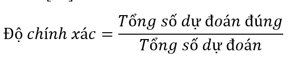

### 6.3.3. Độ đúng đắn - Precision:

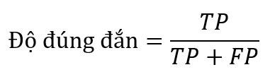

### 6.3.4. Recall:

Recall được định nghĩa là tỉ lệ số điểm dương tính thật trong số những điểm thực sự là dương tính (Dương tính thật + Âm tính giả). Recall cao đồng nghĩa với việc tỉ lệ dương tính thật cao, tức tỉ lệ bỏ sót các điểm thực sự dương tính là thấp.

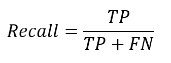

### 6.3.5. F1 - Score:

Điểm F1 là trung bình hài hoà của độ đúng đắn và recall (giả sử rằng hai đại lượng này khác 0). Công thức để tính toán F1-score:

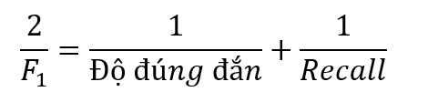

# Phần 7: Mô hình hoá dữ liệu

## 7.1. Biến đổi tập dữ liệu:

Các biến được chọn làm dự đoán cho chuyến bay:

```python
input_cols = ["Month","DayOfWeek","Airline","Origin","Dest","TimeSlot"]
output_col = ["Delayed"]

df_temp1 = sqlContext.read.format(
    "csv").option("header", "true").load("../data/Combined_Flights_2018.csv",
    inferSchema=True)
df_temp2 = sqlContext.read.format(
    "csv").option("header", "true").load("../data/Combined_Flights_2020.csv",
    inferSchema=True)
df_model = df_temp1.union(df_temp2)
```

```python
df_model = df_model.fillna(0)
df_model = df_model.filter((df_model.Cancelled == 0)&(df_model.Diverted == 0))
df_model = df_model.withColumn('Delayed', (df_model.ArrDelay >=15).cast('int'))
sqlContext.registerDataFrameAsTable(df_model, "df_model")
df_model = sqlContext.sql("select *, case \
               when CRSDepTime <= 800 then 1 \
               when 800 < CRSDepTime and CRSDepTime <= 1200 then 2 \
               when 1200 < CRSDepTime and CRSDepTime <= 1600 then 3 \
               when 1600 < CRSDepTime and CRSDepTime <= 2100 then 4 \
               else 1 end as TimeSlot \
               from df_model")
```

```python
stringIndexer = StringIndexer(inputCols=["Airline","Origin","Dest"], outputCols=["Airline_Index","Origin_Index","Dest_Index"])
df_model = stringIndexer.fit(df_model).transform(df_model)
input_cols = ["Month","DayOfWeek","Airline_Index","Origin_Index","Dest_Index","TimeSlot"]
df_model = df_model.select(input_cols+output_col+["Year"])
```

```python
assembler = VectorAssembler(inputCols=input_cols, outputCol="features")
df_model = assembler.transform(df_model)
```

```python
df_model.limit(10).show()
```

```
+-----+---------+-------------+------------+----------+--------+-------+----+--------------------+
|Month|DayOfWeek|Airline_Index|Origin_Index|Dest_Index|TimeSlot|Delayed|Year|            features|
+-----+---------+-------------+------------+----------+--------+-------+----+--------------------+
|    1|        2|         14.0|       311.0|       2.0|       3|      0|2018|[1.0,2.0,14.0,311...|
|    1|        3|         14.0|       311.0|       2.0|       3|      0|2018|[1.0,3.0,14.0,311...|
|    1|        4|         14.0|       311.0|       2.0|       3|      0|2018|[1.0,4.0,14.0,311...|
|    1|        5|         14.0|       311.0|       2.0|       3|      0|2018|[1.0,5.0,14.0,311...|
|    1|        6|         14.0|       311.0|       2.0|       3|      0|2018|[1.0,6.0,14.0,311...|
|    1|        7|         14.0|       311.0|       2.0|       3|      1|2018|[1.0,7.0,14.0,311...|
|    1|        1|         14.0|       311.0|       2.0|       3|      0|2018|[1.0,1.0,14.0,311...|
|    1|        2|         14.0|       311.0|       2.0|       3|      0|2018|[1.0,2.0,14.0,311...|
|    1|        3|         14.0|       311.0|       2.0|       3|      0|2018|[1.0,3.0,14.0,311...|
|    1|        3|         14.0|         2.0|     311.0|       2|      1|2018|[1.0,3.0,14.0,2.0...|
+-----+---------+-------------+------------+----------+--------+-------+----+--------------------+
```

## 7.2. Tạo tập train và test

```python
# Đây là hàm tách theo Ratio theo thứ tự, ví dụ số dòng = 100,
#        ratio 0.8 thì sẽ lấy 80 dòng đầu tiên cho tập train
# Có thể phải sửa lại, lấy 2018 dự đoán cho năm 2019
# def SplitDataSet(df, ratio):
#     total_count = df.count()
#     split_index = int(total_count * ratio)
#     train_df = df.limit(split_index)
#     test_df = df.subtract(train_df)
#     return train_df,test_df

train_df = df_model.filter(df_model.Year == 2018)
test_df = df_model.filter(df_model.Year == 2020)
```

```python
print("Số chuyến bay Delay trong tập train: ",train_df.filter(train_df.Delayed == 1).count())
print("Số chuyến bay không bị Delay trong tập train: ",train_df.filter(train_df.Delayed == 0).count())
```

```
Số chuyến bay Delay trong tập train:  1088342
Số chuyến bay không bị Delay trong tập train:  4498844
```

```python
print("Số chuyến bay Delay trong tập test: ",test_df.filter(test_df.Delayed == 1).count())
print("Số chuyến bay không bị Delay trong tập test: ",test_df.filter(test_df.Delayed == 0).count())
```

```
Số chuyến bay Delay trong tập test:  2854
Số chuyến bay không bị Delay trong tập test:  46575
```

```python
def removeSomeRow_df(train_df,num_of_row):
    window_spec = Window.orderBy(functions.rand())
    df_temp1 = train_df.filter(train_df.Delayed == 1)
    df_temp0 = train_df.filter(train_df.Delayed == 0).withColumn("random_value", functions.row_number().over(window_spec))
    df_temp0 = df_temp0.filter(df_temp0["random_value"]>num_of_row)
    df_temp0 = df_temp0.drop("random_value")
    return df_temp1.union(df_temp0)
```

```python
train_df = removeSomeRow_df(train_df,2000000)
print("Số chuyến bay Delay trong tập train: ",train_df.filter(train_df.Delayed == 1).count())
print("Số chuyến bay không bị Delay trong tập train: ",train_df.filter(train_df.Delayed == 0).count())
```

```
Số chuyến bay Delay trong tập train:  1088342
Số chuyến bay không bị Delay trong tập train:  2498844
```

```python
test_df = removeSomeRow_df(test_df,40000)
print("Số chuyến bay Delay trong tập test: ",test_df.filter(test_df.Delayed == 1).count())
print("Số chuyến bay không bị Delay trong tập test: ",test_df.filter(test_df.Delayed == 0).count())
```

```
Số chuyến bay Delay trong tập test:  2854
Số chuyến bay không bị Delay trong tập test:  6575
```

```python
train_df.limit(5).show()
```

```
+-----+---------+-------------+------------+----------+--------+-------+----+
|Month|DayOfWeek|Airline_Index|Origin_Index|Dest_Index|TimeSlot|Delayed|Year|
+-----+---------+-------------+------------+----------+--------+-------+----+
|    1|        7|         14.0|       311.0|       2.0|       3|      1|2018|
|    1|        3|         14.0|         2.0|     311.0|       2|      1|2018|
|    1|        1|         14.0|         2.0|     311.0|       2|      1|2018|
|    1|        2|         14.0|         2.0|     311.0|       2|      1|2018|
|    1|        4|         14.0|         2.0|     311.0|       2|      1|2018|
+-----+---------+-------------+------------+----------+--------+-------+----+
```

```python
test_df.limit(5).show()
```

```
+-----+---------+-------------+------------+----------+--------+-------+----+
|Month|DayOfWeek|Airline_Index|Origin_Index|Dest_Index|TimeSlot|Delayed|Year|
+-----+---------+-------------+------------+----------+--------+-------+----+
|    9|        5|         13.0|        76.0|       9.0|       4|      1|2020|
|    9|        7|          1.0|        43.0|       4.0|       1|      1|2020|
|    9|        3|          0.0|         1.0|      47.0|       2|      1|2020|
|    9|        6|          7.0|       293.0|     162.0|       2|      1|2020|
|    9|        6|          0.0|        18.0|      30.0|       4|      1|2020|
+-----+---------+-------------+------------+----------+--------+-------+----+
```

## 7.3. Cây quyết định

### 7.3.1. Trước khi tối ưu

```python
dt_classifier = DecisionTreeClassifier(featuresCol="features",labelCol="Delayed",maxBins=400)

model = dt_classifier.fit(train_df)

predictions = model.transform(test_df)
```

```python
evaluator = MulticlassClassificationEvaluator(predictionCol="prediction",labelCol="Delayed", metricName="accuracy")
dt_accuracy = evaluator.evaluate(predictions)
evaluator = MulticlassClassificationEvaluator(labelCol="Delayed", predictionCol="prediction", metricName="f1")
dt_f1 = evaluator.evaluate(predictions)
evaluator = MulticlassClassificationEvaluator(labelCol="Delayed", predictionCol="prediction", metricName="weightedPrecision")
dt_precision = evaluator.evaluate(predictions)
evaluator = MulticlassClassificationEvaluator(labelCol="Delayed", predictionCol="prediction", metricName="weightedRecall")
dt_recall = evaluator.evaluate(predictions)
```

```python
print("accuracy: " + str(dt_accuracy))

print("f1: " + str(dt_f1))

print("precision: " + str(dt_precision))

print("recall: ", dt_recall)
```

```
accuracy: 0.6962562307773889
f1: 0.5751618196018272
precision: 0.5979510596924563
recall:  0.696256230777389
```

### 7.3.2. Sau khi tối ưu

```python
dt_classifier = DecisionTreeClassifier(featuresCol="features",labelCol="Delayed")
evaluator = MulticlassClassificationEvaluator(predictionCol="prediction",labelCol="Delayed", metricName="f1")
paramGrid = ParamGridBuilder() \
    .addGrid(dt_classifier.maxDepth, list(range(3,15,3))) \
    .addGrid(dt_classifier.minInstancesPerNode, list(range(1,10,4))) \
    .addGrid(dt_classifier.maxBins,list(range(400,1000,300)))\
    .build()
crossval = CrossValidator(estimator=dt_classifier,
                          estimatorParamMaps=paramGrid,
                          evaluator=evaluator,
                          numFolds=3
                          )
cvModel = crossval.fit(train_df)
bestModel = cvModel.bestModel
```

```python
predictions = bestModel.transform(test_df)
```

```python
evaluator = MulticlassClassificationEvaluator(labelCol="Delayed", predictionCol="prediction", metricName="accuracy")
dt_optimized_accuracy = evaluator.evaluate(predictions)
evaluator = MulticlassClassificationEvaluator(labelCol="Delayed", predictionCol="prediction", metricName="f1")
dt_optimized_f1 = evaluator.evaluate(predictions)
evaluator = MulticlassClassificationEvaluator(labelCol="Delayed", predictionCol="prediction", metricName="weightedPrecision")
dt_optimized_precision = evaluator.evaluate(predictions)
evaluator = MulticlassClassificationEvaluator(labelCol="Delayed", predictionCol="prediction", metricName="weightedRecall")
dt_optimized_recall = evaluator.evaluate(predictions)
```

```python
print("maxDepth: ",  bestModel._java_obj.getMaxDepth())
print("minInstancesPerNode: ", bestModel.getOrDefault("minInstancesPerNode"))
print("maxBin: ", bestModel.getOrDefault("maxBins"))
```

```
maxDepth:  12
minInstancesPerNode:  5
maxBin:  400
```

```python
print("accuracy: " + str(dt_optimized_accuracy))

print("f1: " + str(dt_optimized_f1))

print("precision: " + str(dt_optimized_precision))

print("recall: ",dt_optimized_recall)
```

```
accuracy: 0.6864990985258246
f1: 0.5802294658485619
precision: 0.5735570657330947
recall:  0.6864990985258246
```

## 7.4. Hồi quy Logistic

### 7.4.1. Trước khi tối ưu:

```python
logistic = LogisticRegression(featuresCol="features",labelCol="Delayed")
model = logistic.fit(train_df)
predictions = model.transform(test_df)
```

```python
evaluator = MulticlassClassificationEvaluator(labelCol="Delayed", predictionCol="prediction", metricName="accuracy")
logistic_accuracy = evaluator.evaluate(predictions)
evaluator = MulticlassClassificationEvaluator(labelCol="Delayed", predictionCol="prediction", metricName="f1")
logistic_f1 = evaluator.evaluate(predictions)
evaluator = MulticlassClassificationEvaluator(labelCol="Delayed", predictionCol="prediction", metricName="weightedPrecision")
logistic_precision = evaluator.evaluate(predictions)
evaluator = MulticlassClassificationEvaluator(labelCol="Delayed", predictionCol="prediction", metricName="weightedRecall")
logistic_recall = evaluator.evaluate(predictions)
```

```python
print("accuracy: " + str(logistic_accuracy))

print("f1: " + str(logistic_f1))

print("precision: " + str(logistic_precision))
print("recall: " + str(logistic_recall))
```

```
accuracy: 0.6973167886308198
f1: 0.5729639946572906
precision: 0.48625070370639945
recall: 0.6973167886308198
```

### 7.4.2. Sau khi tối ưu:

```python
logistic = LogisticRegression(featuresCol="features",labelCol="Delayed")
evaluator = MulticlassClassificationEvaluator(predictionCol="prediction",labelCol="Delayed", metricName="f1")
paramGrid = ParamGridBuilder() \
    .addGrid(logistic.regParam, [0.1, 0.25, 0.4, 0.55, 0.7, 0.85]) \
    .addGrid(logistic.elasticNetParam, [0.1, 0.25, 0.4, 0.55, 0.7, 0.85]) \
    .build()
crossval = CrossValidator(estimator=logistic,
                          estimatorParamMaps=paramGrid,
                          evaluator=evaluator,
                          numFolds=3
                          )
cvModel = crossval.fit(train_df)
bestModel = cvModel.bestModel
```

```python
predictions = bestModel.transform(test_df)
```

```python
evaluator = MulticlassClassificationEvaluator(labelCol="Delayed", predictionCol="prediction", metricName="accuracy")
logistic_optimized_accuracy = evaluator.evaluate(predictions)
evaluator = MulticlassClassificationEvaluator(labelCol="Delayed", predictionCol="prediction", metricName="f1")
logistic_optimized_f1 = evaluator.evaluate(predictions)
evaluator = MulticlassClassificationEvaluator(labelCol="Delayed", predictionCol="prediction", metricName="weightedPrecision")
logistic_optimized_precision = evaluator.evaluate(predictions)
evaluator = MulticlassClassificationEvaluator(labelCol="Delayed", predictionCol="prediction", metricName="weightedRecall")
logistic_optimized_recall = evaluator.evaluate(predictions)
```

```python
print("regParam: ", bestModel._java_obj.getRegParam())
print("elasticNetParam: ", bestModel._java_obj.getElasticNetParam())
```

```
regParam:  0.1
elasticNetParam:  0.1
```

```python
print("accuracy: " + str(logistic_optimized_accuracy))

print("f1: " + str(logistic_optimized_f1))

print("precision: " + str(logistic_optimized_precision))

print("recall: " + str(logistic_optimized_recall))
```

```
accuracy: 0.6973167886308198
f1: 0.5729639946572906
precision: 0.48625070370639945
recall: 0.6973167886308198
```

## 7.5. Rừng ngẫu nhiên

### 7.5.1 Trước khi tối ưu:

```python
rdf = RandomForestClassifier(featuresCol="features",labelCol="Delayed",maxBins=400)
model = rdf.fit(train_df)
predictions = model.transform(test_df)
```

```python
evaluator = MulticlassClassificationEvaluator(labelCol="Delayed", predictionCol="prediction", metricName="accuracy")
rdf_accuracy = evaluator.evaluate(predictions)

evaluator = MulticlassClassificationEvaluator(labelCol="Delayed", predictionCol="prediction", metricName="f1")
rdf_f1 = evaluator.evaluate(predictions)

evaluator = MulticlassClassificationEvaluator(labelCol="Delayed", predictionCol="prediction", metricName="weightedPrecision")
rdf_precision = evaluator.evaluate(predictions)
evaluator = MulticlassClassificationEvaluator(labelCol="Delayed", predictionCol="prediction", metricName="weightedRecall")
rdf_recall = evaluator.evaluate(predictions)
```

```python
print("accuracy: " + str(rdf_accuracy))

print("f1: " + str(rdf_f1))

print("precision: " + str(rdf_precision))

print("recall: " + str(rdf_recall))
```

```
accuracy: 0.6969986212747905
f1: 0.5728099412388911
precision: 0.4861835279950932
recall: 0.6969986212747905
```

### 7.5.2 Sau khi tối ưu:

```python
rdf = RandomForestClassifier(featuresCol="features",labelCol="Delayed",maxBins=400)
evaluator = MulticlassClassificationEvaluator(predictionCol="prediction",labelCol="Delayed", metricName="f1")
paramGrid = ParamGridBuilder() \
    .addGrid(rdf.maxDepth, [5,10,15])\
    .addGrid(rdf.numTrees, [5,7])\
    .build()
crossval = CrossValidator(estimator=rdf,
                          estimatorParamMaps=paramGrid,
                          evaluator=evaluator,
                          numFolds=2
                          )
cvModel = crossval.fit(train_df)
bestModel = cvModel.bestModel
```

```python
predictions = bestModel.transform(test_df)
```

```python
evaluator = MulticlassClassificationEvaluator(labelCol="Delayed", predictionCol="prediction", metricName="accuracy")
rf_optimized_accuracy = evaluator.evaluate(predictions)
evaluator = MulticlassClassificationEvaluator(labelCol="Delayed", predictionCol="prediction", metricName="f1")
rf_optimized_f1 = evaluator.evaluate(predictions)
evaluator = MulticlassClassificationEvaluator(labelCol="Delayed", predictionCol="prediction", metricName="weightedPrecision")
rf_optimized_precision = evaluator.evaluate(predictions)
evaluator = MulticlassClassificationEvaluator(labelCol="Delayed", predictionCol="prediction", metricName="weightedRecall")
rf_optimized_recall = evaluator.evaluate(predictions)
```

```python
print("maxDepth: ", bestModel._java_obj.getMaxDepth())
print("numTrees: ",bestModel._java_obj.getNumTrees())
```

```
maxDepth:  15
numTrees:  5
```

```python
print("accuracy: " + str(rf_optimized_accuracy))

print("f1: " + str(rf_optimized_f1))

print("precision: " + str(rf_optimized_precision))

print("recall: " + str(rf_optimized_recall))
```

```
accuracy: 0.6958320076360165
f1: 0.5762838227720252
precision: 0.6000581937700639
recall: 0.6958320076360165
```

## 7.6. Naive Bayes

### 7.6.1 Trước khi tối ưu:

```python
nb = NaiveBayes(featuresCol="features",labelCol="Delayed")
model = nb.fit(train_df)
predictions = model.transform(test_df)
```

```python
evaluator = MulticlassClassificationEvaluator(labelCol="Delayed", predictionCol="prediction", metricName="accuracy")
nb_accuracy = evaluator.evaluate(predictions)
evaluator = MulticlassClassificationEvaluator(labelCol="Delayed", predictionCol="prediction", metricName="f1")
nb_f1 = evaluator.evaluate(predictions)
evaluator = MulticlassClassificationEvaluator(labelCol="Delayed", predictionCol="prediction", metricName="weightedPrecision")
nb_precision = evaluator.evaluate(predictions)
evaluator = MulticlassClassificationEvaluator(labelCol="Delayed", predictionCol="prediction", metricName="weightedRecall")
nb_recall = evaluator.evaluate(predictions)
```

```python
print("accuracy: " + str(nb_accuracy))

print("f1: " + str(nb_f1))

print("precision: " + str(nb_precision))

print("recall: " + str(nb_recall))
```

```
accuracy: 0.5940184537066497
f1: 0.5962549617720538
precision: 0.5986518359718374
recall: 0.5940184537066497
```

### 7.6.2 Sau khi tối ưu:

```python
nb = NaiveBayes(featuresCol="features",labelCol="Delayed")
evaluator = MulticlassClassificationEvaluator(predictionCol="prediction",labelCol="Delayed", metricName="f1")
paramGrid = ParamGridBuilder() \
    .addGrid(nb.smoothing, [0.1, 0.3, 0.5, 0.7, 0.9]) \
    .build()
crossval = CrossValidator(estimator=nb,
                          estimatorParamMaps=paramGrid,
                          evaluator=evaluator,
                          numFolds=3
                          )
cvModel = crossval.fit(train_df)
bestModel = cvModel.bestModel
```

```python
predictions = bestModel.transform(test_df)
```

```python
evaluator = MulticlassClassificationEvaluator(labelCol="Delayed", predictionCol="prediction", metricName="accuracy")
nb_optimized_accuracy = evaluator.evaluate(predictions)
evaluator = MulticlassClassificationEvaluator(labelCol="Delayed", predictionCol="prediction", metricName="f1")
nb_optimized_f1 = evaluator.evaluate(predictions)
evaluator = MulticlassClassificationEvaluator(labelCol="Delayed", predictionCol="prediction", metricName="weightedPrecision")
nb_optimized_precision = evaluator.evaluate(predictions)
evaluator = MulticlassClassificationEvaluator(labelCol="Delayed", predictionCol="prediction", metricName="weightedRecall")
nb_optimized_recall = evaluator.evaluate(predictions)
```

```python
print("smoothing: ", bestModel._java_obj.getSmoothing())
```

```
smoothing:  0.1
```

```python
print("accuracy: " + str(nb_optimized_accuracy))

print("f1: " + str(nb_optimized_f1))

print("precision: " + str(nb_optimized_precision))

print("recall: " + str(nb_optimized_recall))
```

```
accuracy: 0.5955032347014529
f1: 0.5979146592650929
precision: 0.6005162149442512
recall: 0.5955032347014529
```